# Using R with biological datasets 2026

Author

Daniel Brewer

# Install libraries script

```r
using<-function(...) {
    libs<-unlist(list(...))
    req<-unlist(lapply(libs,require,character.only=TRUE))
    need<-libs[req==FALSE]
    if(length(need)>0){
        install.packages(need)
        lapply(need,require,character.only=TRUE)
    }
}
using("tidyverse","janitor","palmerpenguins","rstatix","ggpubr","skimr",
      "messy","ggsurvfit","survminer")
```

# Tidyverse and data exploration

## Structuring data

Spreadsheet example:

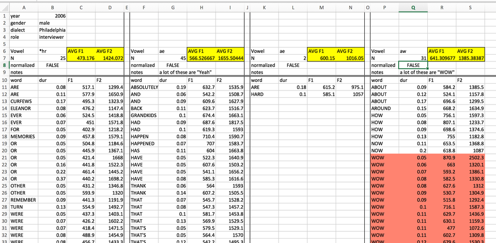

This spreadsheet has a fairly strict organisational structure, but is virtually hopeless for doing any kind of serious statistical analysis. It’s also verging on irreparable using R. This because the data in this spreadsheet is organised to be easy to look at with your eyeballs.

Follow these rules:

1. The first row of the data *must* be the names of the data columns.
2. All other rows *must* be the data, and nothing else.
3. You cannot use empty rows or empty columns as visual aids to look at the data.
4. Do not use colour or other formatting to indicate information.
5. The spreadsheet must not contain any summary cells. No final row called “Average” or final column called “Total”. We can create these in R, and they make data processing more complicated if they’re included in the raw data.

## Tidy tables

You can represent the same underlying data in multiple ways, but they are not equally easy to use. There is one approach that makes it easier to work with “tidy tables”.

There are three interrelated rules that make a dataset tidy:

1. Each variable is a column; each column is a variable.
2. Each observation is a row; each row is an observation.
3. Each value is a cell; each cell is a single value.

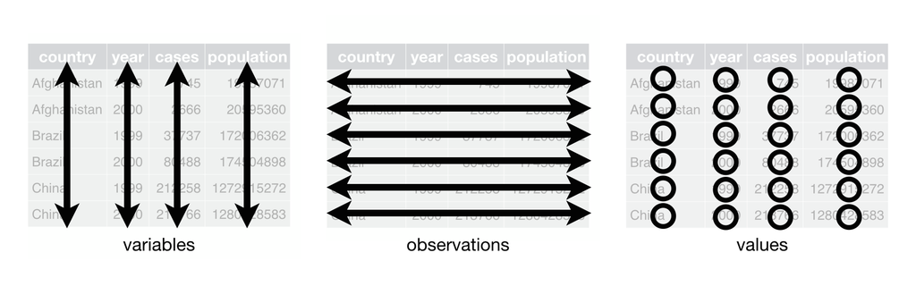

Why ensure that your data is tidy? There are two main advantages:

- There’s a general advantage to picking one consistent way of storing data. If you have a consistent data structure, it’s easier to learn the tools that work with it because they have an underlying uniformity.
- There’s a specific advantage to placing variables in columns because it allows R’s vectorized nature to shine. That makes transforming tidy data feel particularly natural.

An example of an untidy table:

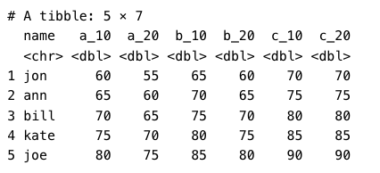

This is some made-up data for five different patients (Jon, Ann, Bill, Kate, and Joe) given three different drugs (A, B, and C), at two doses (10 and 20), and measuring their heart rate.

Tidy version:

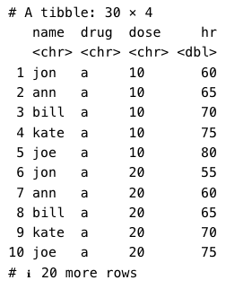

## Exploratory Data Analysis (EDA)

Exploratory data analysis is an approach of analysing data sets to summarise their main characteristics. It is the first thing you should do with any data set you have access to, and R has a few functions to make this easier.

### The Iris data set

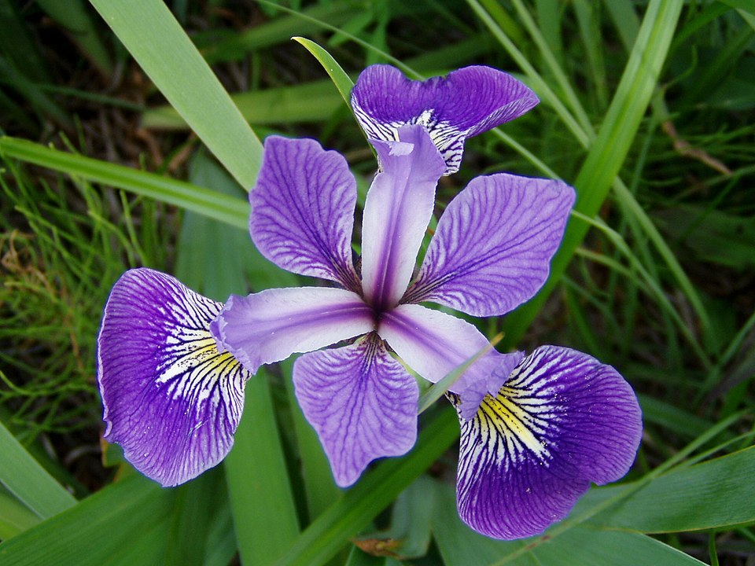

- The Iris flower data set or Fisher’s Iris data set is a multivariate data set used and made famous by the British statistician and biologist Ronald Fisher in a 1936 paper.
- The data set consists of 50 samples from each of three species of Iris (Iris setosa, Iris virginica and Iris versicolor).
- Four features were measured from each sample: the length and the width of the sepals and petals, in centimeters.

### `summary()`

When `summary()` is applied to a data frame it produce some simple summary statistics of all the columns.

- For continuous variables it provides minimum, maximum, median, mean, and quartiles values, as well as any missing data.
- For factors it provides the count of each factor and the number of missing values.

```r
summary(iris)
```

```
  Sepal.Length    Sepal.Width     Petal.Length    Petal.Width
 Min.   :4.300   Min.   :2.000   Min.   :1.000   Min.   :0.100
 1st Qu.:5.100   1st Qu.:2.800   1st Qu.:1.600   1st Qu.:0.300
 Median :5.800   Median :3.000   Median :4.350   Median :1.300
 Mean   :5.843   Mean   :3.057   Mean   :3.758   Mean   :1.199
 3rd Qu.:6.400   3rd Qu.:3.300   3rd Qu.:5.100   3rd Qu.:1.800
 Max.   :7.900   Max.   :4.400   Max.   :6.900   Max.   :2.500
       Species
 setosa    :50
 versicolor:50
 virginica :50
```

### `glimpse()`

`glimpse()` provides a peak at your data. For each column, it provides the type of variable and the first few values. It is in an easy to read format for even large data frames with each row being a different column.

```r
glimpse(iris)
```

```
Rows: 150
Columns: 5
$ Sepal.Length <dbl> 5.1, 4.9, 4.7, 4.6, 5.0, 5.4, 4.6, 5.0, 4.4, 4.9, 5.4, 4.…
$ Sepal.Width  <dbl> 3.5, 3.0, 3.2, 3.1, 3.6, 3.9, 3.4, 3.4, 2.9, 3.1, 3.7, 3.…
$ Petal.Length <dbl> 1.4, 1.4, 1.3, 1.5, 1.4, 1.7, 1.4, 1.5, 1.4, 1.5, 1.5, 1.…
$ Petal.Width  <dbl> 0.2, 0.2, 0.2, 0.2, 0.2, 0.4, 0.3, 0.2, 0.2, 0.1, 0.2, 0.…
$ Species      <fct> setosa, setosa, setosa, setosa, setosa, setosa, setosa, s…
```

### skimr

`skimr` provides a frictionless approach to summary statistics which conforms to the [principle of least surprise](https://en.wikipedia.org/wiki/Principle_of_least_astonishment), displaying summary statistics the user can skim quickly to understand their data. - Provides a larger set of statistics than `summary()`, including missing, complete, n, and sd. - reports each data types separately - handles dates, logicals, and a variety of other types - supports console text graphs

```r
library(skimr)
skim(iris)
```

Data summary

| Name | iris |
| --- | --- |
| Number of rows | 150 |
| Number of columns | 5 |
| _______________________ |  |
| Column type frequency: |  |
| factor | 1 |
| numeric | 4 |
| ________________________ |  |
| Group variables | None |

**Variable type: factor**

| skim_variable | n_missing | complete_rate | ordered | n_unique | top_counts |
| --- | --- | --- | --- | --- | --- |
| Species | 0 | 1 | FALSE | 3 | set: 50, ver: 50, vir: 50 |

**Variable type: numeric**

| skim_variable | n_missing | complete_rate | mean | sd | p0 | p25 | p50 | p75 | p100 | hist |
| --- | --- | --- | --- | --- | --- | --- | --- | --- | --- | --- |
| Sepal.Length | 0 | 1 | 5.84 | 0.83 | 4.3 | 5.1 | 5.80 | 6.4 | 7.9 | ▆▇▇▅▂ |
| Sepal.Width | 0 | 1 | 3.06 | 0.44 | 2.0 | 2.8 | 3.00 | 3.3 | 4.4 | ▁▆▇▂▁ |
| Petal.Length | 0 | 1 | 3.76 | 1.77 | 1.0 | 1.6 | 4.35 | 5.1 | 6.9 | ▇▁▆▇▂ |
| Petal.Width | 0 | 1 | 1.20 | 0.76 | 0.1 | 0.3 | 1.30 | 1.8 | 2.5 | ▇▁▇▅▃ |

### Exercise - EDA

#### Introduction

Here we are going to use the `palmerpenguins` dataset. Data were collected and made available by [Dr. Kristen Gorman](https://www.uaf.edu/cfos/people/faculty/detail/kristen-gorman.php) and the [Palmer Station, Antarctica LTER](https://pallter.marine.rutgers.edu/), a member of the [Long Term Ecological Research Network](https://lternet.edu/).

#### Setup script

```r
library(tidyverse)
library(palmerpenguins)
library(skimr)
```

#### Tasks

Using the `penguins` data:

1. Apply the `summary()` function
2. Apply the `glimpse()` function
3. Apply the `skim()` function

#### Answer

```r
summary(penguins)
```

```
      species          island    bill_length_mm  bill_depth_mm
 Adelie   :152   Biscoe   :168   Min.   :32.10   Min.   :13.10
 Chinstrap: 68   Dream    :124   1st Qu.:39.23   1st Qu.:15.60
 Gentoo   :124   Torgersen: 52   Median :44.45   Median :17.30
                                 Mean   :43.92   Mean   :17.15
                                 3rd Qu.:48.50   3rd Qu.:18.70
                                 Max.   :59.60   Max.   :21.50
                                 NA's   :2       NA's   :2
 flipper_length_mm  body_mass_g       sex           year
 Min.   :172.0     Min.   :2700   female:165   Min.   :2007
 1st Qu.:190.0     1st Qu.:3550   male  :168   1st Qu.:2007
 Median :197.0     Median :4050   NA's  : 11   Median :2008
 Mean   :200.9     Mean   :4202                Mean   :2008
 3rd Qu.:213.0     3rd Qu.:4750                3rd Qu.:2009
 Max.   :231.0     Max.   :6300                Max.   :2009
 NA's   :2         NA's   :2
```

```r
glimpse(penguins)
```

```
Rows: 344
Columns: 8
$ species           <fct> Adelie, Adelie, Adelie, Adelie, Adelie, Adelie, Adel…
$ island            <fct> Torgersen, Torgersen, Torgersen, Torgersen, Torgerse…
$ bill_length_mm    <dbl> 39.1, 39.5, 40.3, NA, 36.7, 39.3, 38.9, 39.2, 34.1, …
$ bill_depth_mm     <dbl> 18.7, 17.4, 18.0, NA, 19.3, 20.6, 17.8, 19.6, 18.1, …
$ flipper_length_mm <int> 181, 186, 195, NA, 193, 190, 181, 195, 193, 190, 186…
$ body_mass_g       <int> 3750, 3800, 3250, NA, 3450, 3650, 3625, 4675, 3475, …
$ sex               <fct> male, female, female, NA, female, male, female, male…
$ year              <int> 2007, 2007, 2007, 2007, 2007, 2007, 2007, 2007, 2007…
```

```r
skim(penguins)
```

Data summary

| Name | penguins |
| --- | --- |
| Number of rows | 344 |
| Number of columns | 8 |
| _______________________ |  |
| Column type frequency: |  |
| factor | 3 |
| numeric | 5 |
| ________________________ |  |
| Group variables | None |

**Variable type: factor**

| skim_variable | n_missing | complete_rate | ordered | n_unique | top_counts |
| --- | --- | --- | --- | --- | --- |
| species | 0 | 1.00 | FALSE | 3 | Ade: 152, Gen: 124, Chi: 68 |
| island | 0 | 1.00 | FALSE | 3 | Bis: 168, Dre: 124, Tor: 52 |
| sex | 11 | 0.97 | FALSE | 2 | mal: 168, fem: 165 |

**Variable type: numeric**

| skim_variable | n_missing | complete_rate | mean | sd | p0 | p25 | p50 | p75 | p100 | hist |
| --- | --- | --- | --- | --- | --- | --- | --- | --- | --- | --- |
| bill_length_mm | 2 | 0.99 | 43.92 | 5.46 | 32.1 | 39.23 | 44.45 | 48.5 | 59.6 | ▃▇▇▆▁ |
| bill_depth_mm | 2 | 0.99 | 17.15 | 1.97 | 13.1 | 15.60 | 17.30 | 18.7 | 21.5 | ▅▅▇▇▂ |
| flipper_length_mm | 2 | 0.99 | 200.92 | 14.06 | 172.0 | 190.00 | 197.00 | 213.0 | 231.0 | ▂▇▃▅▂ |
| body_mass_g | 2 | 0.99 | 4201.75 | 801.95 | 2700.0 | 3550.00 | 4050.00 | 4750.0 | 6300.0 | ▃▇▆▃▂ |
| year | 0 | 1.00 | 2008.03 | 0.82 | 2007.0 | 2007.00 | 2008.00 | 2009.0 | 2009.0 | ▇▁▇▁▇ |

## Data Manipulation with dplyr

The `dplyr` package gives you a handful of useful **verbs** for managing data. What they have in common:

1. The first argument is always a data frame.
2. The subsequent arguments typically describe which columns to operate on using the variable names (without quotes).
3. The output is always a new data frame.

The data we’re going to look at is cleaned up version of a gene expression dataset from [Brauer et al. Coordination of Growth Rate, Cell Cycle, Stress Response, and Metabolic Activity in Yeast (2008) *Mol Biol Cell* 19:352-367](http://www.ncbi.nlm.nih.gov/pubmed/17959824) - `bauer`. This data is from a gene expression microarray, and in this paper the authors are examining the relationship between growth rate and gene expression in yeast cultures limited by one of six different nutrients (glucose, leucine, ammonium, sulfate, phosphate, uracil).

```
# A tibble: 198,430 × 7
   symbol systematic_name nutrient  rate expression bp                     mf
   <chr>  <chr>           <chr>    <dbl>      <dbl> <chr>                  <chr>
 1 SFB2   YNL049C         Glucose   0.05      -0.24 ER to Golgi transport  mole…
 2 <NA>   YNL095C         Glucose   0.05       0.28 biological process un… mole…
 3 QRI7   YDL104C         Glucose   0.05      -0.02 proteolysis and pepti… meta…
 4 CFT2   YLR115W         Glucose   0.05      -0.33 mRNA polyadenylylatio… RNA …
 5 SSO2   YMR183C         Glucose   0.05       0.05 vesicle fusion*        t-SN…
 6 PSP2   YML017W         Glucose   0.05      -0.69 biological process un… mole…
 7 RIB2   YOL066C         Glucose   0.05      -0.55 riboflavin biosynthes… pseu…
 8 VMA13  YPR036W         Glucose   0.05      -0.75 vacuolar acidification hydr…
 9 EDC3   YEL015W         Glucose   0.05      -0.24 deadenylylation-indep… mole…
10 VPS5   YOR069W         Glucose   0.05      -0.16 protein retention in … prot…
# ℹ 198,420 more rows
```

```
Rows: 198,430
Columns: 7
$ symbol          <chr> "SFB2", NA, "QRI7", "CFT2", "SSO2", "PSP2", "RIB2", "V…
$ systematic_name <chr> "YNL049C", "YNL095C", "YDL104C", "YLR115W", "YMR183C",…
$ nutrient        <chr> "Glucose", "Glucose", "Glucose", "Glucose", "Glucose",…
$ rate            <dbl> 0.05, 0.05, 0.05, 0.05, 0.05, 0.05, 0.05, 0.05, 0.05, …
$ expression      <dbl> -0.24, 0.28, -0.02, -0.33, 0.05, -0.69, -0.55, -0.75, …
$ bp              <chr> "ER to Golgi transport", "biological process unknown",…
$ mf              <chr> "molecular function unknown", "molecular function unkn…
```

### `filter()`

If you want to filter **rows** of the data where some condition is true, use the `filter()` function.

1. The first argument is the data frame you want to filter, e.g. `filter(mydata, ...`.
2. The second argument is a condition you must satisfy, e.g. `filter(ydat, symbol == "LEU1")`. If you want to satisfy *all* of multiple conditions, you can use the “and” operator, `&`. The “or” operator `|` (the pipe character, usually shift-backslash) will return a subset that meet *any* of the conditions.
- `==`: Equal to
- `!=`: Not equal to
- `>`, `>=`: Greater than, greater than or equal to
- `<`, `<=`: Less than, less than or equal to

```r
# Look at a single gene involved in leucine synthesis pathway
filter(brauer, symbol == "LEU1")
```

```
# A tibble: 36 × 7
   symbol systematic_name nutrient  rate expression bp                   mf
   <chr>  <chr>           <chr>    <dbl>      <dbl> <chr>                <chr>
 1 LEU1   YGL009C         Glucose   0.05      -1.12 leucine biosynthesis 3-isop…
 2 LEU1   YGL009C         Glucose   0.1       -0.77 leucine biosynthesis 3-isop…
 3 LEU1   YGL009C         Glucose   0.15      -0.67 leucine biosynthesis 3-isop…
 4 LEU1   YGL009C         Glucose   0.2       -0.59 leucine biosynthesis 3-isop…
 5 LEU1   YGL009C         Glucose   0.25      -0.2  leucine biosynthesis 3-isop…
 6 LEU1   YGL009C         Glucose   0.3        0.03 leucine biosynthesis 3-isop…
 7 LEU1   YGL009C         Ammonia   0.05      -0.76 leucine biosynthesis 3-isop…
 8 LEU1   YGL009C         Ammonia   0.1       -1.17 leucine biosynthesis 3-isop…
 9 LEU1   YGL009C         Ammonia   0.15      -1.2  leucine biosynthesis 3-isop…
10 LEU1   YGL009C         Ammonia   0.2       -1.02 leucine biosynthesis 3-isop…
# ℹ 26 more rows
```

```r
# Look at multiple genes
filter(brauer, symbol=="LEU1" | symbol=="ADH2")
```

```
# A tibble: 72 × 7
   symbol systematic_name nutrient  rate expression bp                   mf
   <chr>  <chr>           <chr>    <dbl>      <dbl> <chr>                <chr>
 1 LEU1   YGL009C         Glucose   0.05      -1.12 leucine biosynthesis 3-isop…
 2 ADH2   YMR303C         Glucose   0.05       6.28 fermentation*        alcoho…
 3 LEU1   YGL009C         Glucose   0.1       -0.77 leucine biosynthesis 3-isop…
 4 ADH2   YMR303C         Glucose   0.1        5.81 fermentation*        alcoho…
 5 LEU1   YGL009C         Glucose   0.15      -0.67 leucine biosynthesis 3-isop…
 6 ADH2   YMR303C         Glucose   0.15       5.64 fermentation*        alcoho…
 7 LEU1   YGL009C         Glucose   0.2       -0.59 leucine biosynthesis 3-isop…
 8 ADH2   YMR303C         Glucose   0.2        5.1  fermentation*        alcoho…
 9 LEU1   YGL009C         Glucose   0.25      -0.2  leucine biosynthesis 3-isop…
10 ADH2   YMR303C         Glucose   0.25       1.89 fermentation*        alcoho…
# ℹ 62 more rows
```

```r
# Look at LEU1 expression at a low growth rate due to nutrient depletion
# Notice how LEU1 is highly upregulated when leucine is depleted!
filter(brauer, symbol=="LEU1" & rate==.05)
```

```
# A tibble: 6 × 7
  symbol systematic_name nutrient   rate expression bp                   mf
  <chr>  <chr>           <chr>     <dbl>      <dbl> <chr>                <chr>
1 LEU1   YGL009C         Glucose    0.05      -1.12 leucine biosynthesis 3-isop…
2 LEU1   YGL009C         Ammonia    0.05      -0.76 leucine biosynthesis 3-isop…
3 LEU1   YGL009C         Phosphate  0.05      -0.81 leucine biosynthesis 3-isop…
4 LEU1   YGL009C         Sulfate    0.05      -1.57 leucine biosynthesis 3-isop…
5 LEU1   YGL009C         Leucine    0.05       3.84 leucine biosynthesis 3-isop…
6 LEU1   YGL009C         Uracil     0.05      -2.07 leucine biosynthesis 3-isop…
```

### `arrange()`

The `arrange()` function does what it sounds like. It takes a data frame and arranges (or sorts) by column(s) of interest. The first argument is the data, and subsequent arguments are columns to sort on. Use the `desc()` function to arrange by descending.

```r
# arrange by expression (default: increasing)
arrange(brauer, expression)
```

```
# A tibble: 198,430 × 7
   symbol systematic_name nutrient   rate expression bp                    mf
   <chr>  <chr>           <chr>     <dbl>      <dbl> <chr>                 <chr>
 1 SUL1   YBR294W         Phosphate  0.05      -6.5  sulfate transport     sulf…
 2 SUL1   YBR294W         Phosphate  0.1       -6.34 sulfate transport     sulf…
 3 ADH2   YMR303C         Phosphate  0.1       -6.15 fermentation*         alco…
 4 ADH2   YMR303C         Phosphate  0.3       -6.04 fermentation*         alco…
 5 ADH2   YMR303C         Phosphate  0.25      -5.89 fermentation*         alco…
 6 SUL1   YBR294W         Uracil     0.05      -5.55 sulfate transport     sulf…
 7 SFC1   YJR095W         Phosphate  0.2       -5.52 fumarate transport*   succ…
 8 JEN1   YKL217W         Phosphate  0.3       -5.44 lactate transport     lact…
 9 MHT1   YLL062C         Phosphate  0.05      -5.36 sulfur amino acid me… homo…
10 SFC1   YJR095W         Phosphate  0.25      -5.35 fumarate transport*   succ…
# ℹ 198,420 more rows
```

```r
# arrange by decreasing expression
arrange(brauer, desc(expression))
```

```
# A tibble: 198,430 × 7
   symbol systematic_name nutrient   rate expression bp                    mf
   <chr>  <chr>           <chr>     <dbl>      <dbl> <chr>                 <chr>
 1 GAP1   YKR039W         Ammonia    0.05       6.64 amino acid transport* L-pr…
 2 DAL5   YJR152W         Ammonia    0.05       6.64 allantoate transport  alla…
 3 GAP1   YKR039W         Ammonia    0.1        6.64 amino acid transport* L-pr…
 4 DAL5   YJR152W         Ammonia    0.1        6.64 allantoate transport  alla…
 5 DAL5   YJR152W         Ammonia    0.15       6.64 allantoate transport  alla…
 6 DAL5   YJR152W         Ammonia    0.2        6.64 allantoate transport  alla…
 7 DAL5   YJR152W         Ammonia    0.25       6.64 allantoate transport  alla…
 8 DAL5   YJR152W         Ammonia    0.3        6.64 allantoate transport  alla…
 9 GIT1   YCR098C         Phosphate  0.05       6.64 glycerophosphodieste… glyc…
10 PHM6   YDR281C         Phosphate  0.05       6.64 biological process u… mole…
# ℹ 198,420 more rows
```

### Exercise - Data Manipulation with dplyr

#### Introduction

We will be applying filtering and arranging functions to the Brauer *et al.* dataset

#### Setup script

```r
library(tidyverse)
brauer <- read_csv(file="https://raw.githubusercontent.com/UEA-Cancer-Genetics-Lab/Using-R-with-biological-datasets-2025/a51b10274d020b15453e6ee0ab7f6e7963327bd5/data/brauer2007_tidy.csv")
```

#### Tasks

1. Display the data where the gene ontology biological process (the `bp` variable) is “leucine biosynthesis” (case-sensitive) *and* the limiting nutrient was Leucine. (Answer should return a 24-by-7 data frame – 4 genes × 6 growth rates).
2. Wrap this entire filtered result with a call to `arrange()` where you’ll arrange the result of #1 by the gene symbol.

#### Answer

```r
library(tidyverse)
brauer <- read_csv(file="https://raw.githubusercontent.com/UEA-Cancer-Genetics-Lab/Using-R-with-biological-datasets-2025/a51b10274d020b15453e6ee0ab7f6e7963327bd5/data/brauer2007_tidy.csv")
#1
filter(brauer, bp == "leucine biosynthesis" & nutrient == "Leucine")
```

```
# A tibble: 24 × 7
   symbol systematic_name nutrient  rate expression bp                   mf
   <chr>  <chr>           <chr>    <dbl>      <dbl> <chr>                <chr>
 1 LEU9   YOR108W         Leucine   0.05       0.44 leucine biosynthesis 2-isop…
 2 LEU1   YGL009C         Leucine   0.05       3.84 leucine biosynthesis 3-isop…
 3 LEU2   YCL018W         Leucine   0.05       1.54 leucine biosynthesis 3-isop…
 4 LEU4   YNL104C         Leucine   0.05       1.94 leucine biosynthesis 2-isop…
 5 LEU9   YOR108W         Leucine   0.1        0.57 leucine biosynthesis 2-isop…
 6 LEU1   YGL009C         Leucine   0.1        3.36 leucine biosynthesis 3-isop…
 7 LEU2   YCL018W         Leucine   0.1        1.23 leucine biosynthesis 3-isop…
 8 LEU4   YNL104C         Leucine   0.1        1.71 leucine biosynthesis 2-isop…
 9 LEU9   YOR108W         Leucine   0.15       0.46 leucine biosynthesis 2-isop…
10 LEU1   YGL009C         Leucine   0.15       3.24 leucine biosynthesis 3-isop…
# ℹ 14 more rows
```

```r
#2
arrange(filter(brauer, bp == "leucine biosynthesis" & nutrient == "Leucine"), symbol)
```

```
# A tibble: 24 × 7
   symbol systematic_name nutrient  rate expression bp                   mf
   <chr>  <chr>           <chr>    <dbl>      <dbl> <chr>                <chr>
 1 LEU1   YGL009C         Leucine   0.05       3.84 leucine biosynthesis 3-isop…
 2 LEU1   YGL009C         Leucine   0.1        3.36 leucine biosynthesis 3-isop…
 3 LEU1   YGL009C         Leucine   0.15       3.24 leucine biosynthesis 3-isop…
 4 LEU1   YGL009C         Leucine   0.2        2.84 leucine biosynthesis 3-isop…
 5 LEU1   YGL009C         Leucine   0.25       2.04 leucine biosynthesis 3-isop…
 6 LEU1   YGL009C         Leucine   0.3        0.87 leucine biosynthesis 3-isop…
 7 LEU2   YCL018W         Leucine   0.05       1.54 leucine biosynthesis 3-isop…
 8 LEU2   YCL018W         Leucine   0.1        1.23 leucine biosynthesis 3-isop…
 9 LEU2   YCL018W         Leucine   0.15       0.69 leucine biosynthesis 3-isop…
10 LEU2   YCL018W         Leucine   0.2        0.39 leucine biosynthesis 3-isop…
# ℹ 14 more rows
```

### `select()`

The `filter()` function allows you to return only certain *rows* matching a condition. The `select()` function returns only certain *columns*. The first argument is the data, and subsequent arguments are the columns you want.

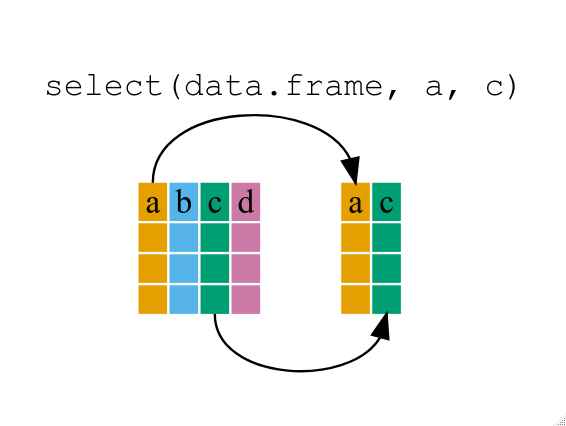

```r
# Select just the symbol and systematic_name
select(brauer, symbol, systematic_name)
```

```
# A tibble: 198,430 × 2
   symbol systematic_name
   <chr>  <chr>
 1 SFB2   YNL049C
 2 <NA>   YNL095C
 3 QRI7   YDL104C
 4 CFT2   YLR115W
 5 SSO2   YMR183C
 6 PSP2   YML017W
 7 RIB2   YOL066C
 8 VMA13  YPR036W
 9 EDC3   YEL015W
10 VPS5   YOR069W
# ℹ 198,420 more rows
```

```r
# Alternatively, just remove columns. Remove the bp and mf columns.
select(brauer, -bp, -mf)
```

```
# A tibble: 198,430 × 5
   symbol systematic_name nutrient  rate expression
   <chr>  <chr>           <chr>    <dbl>      <dbl>
 1 SFB2   YNL049C         Glucose   0.05      -0.24
 2 <NA>   YNL095C         Glucose   0.05       0.28
 3 QRI7   YDL104C         Glucose   0.05      -0.02
 4 CFT2   YLR115W         Glucose   0.05      -0.33
 5 SSO2   YMR183C         Glucose   0.05       0.05
 6 PSP2   YML017W         Glucose   0.05      -0.69
 7 RIB2   YOL066C         Glucose   0.05      -0.55
 8 VMA13  YPR036W         Glucose   0.05      -0.75
 9 EDC3   YEL015W         Glucose   0.05      -0.24
10 VPS5   YOR069W         Glucose   0.05      -0.16
# ℹ 198,420 more rows
```

These functions do not change the original data. You need to assign the results to another variable if you want to keep them.

```r
# create a new dataset without the go annotations.
nogo <- select(brauer, -bp, -mf)
nogo
```

```
# A tibble: 198,430 × 5
   symbol systematic_name nutrient  rate expression
   <chr>  <chr>           <chr>    <dbl>      <dbl>
 1 SFB2   YNL049C         Glucose   0.05      -0.24
 2 <NA>   YNL095C         Glucose   0.05       0.28
 3 QRI7   YDL104C         Glucose   0.05      -0.02
 4 CFT2   YLR115W         Glucose   0.05      -0.33
 5 SSO2   YMR183C         Glucose   0.05       0.05
 6 PSP2   YML017W         Glucose   0.05      -0.69
 7 RIB2   YOL066C         Glucose   0.05      -0.55
 8 VMA13  YPR036W         Glucose   0.05      -0.75
 9 EDC3   YEL015W         Glucose   0.05      -0.24
10 VPS5   YOR069W         Glucose   0.05      -0.16
# ℹ 198,420 more rows
```

### `mutate()`

The `mutate()` function adds new columns to the data based on other columns.

The expression level reported here is the $log_2$ of the sample signal divided by the signal in the reference channel, where the reference RNA for all samples was taken from the glucose-limited chemostat grown at a dilution rate of $0.25 h^{−1}$. Let’s mutate this data to add a new variable called “signal” that’s the actual raw signal ratio instead of the log-transformed signal. Let’s make another column that’s the square root of the signal ratio.

```r
mutate(nogo, signal=2^expression, sigsr=sqrt(signal))
```

```
# A tibble: 198,430 × 7
   symbol systematic_name nutrient  rate expression signal sigsr
   <chr>  <chr>           <chr>    <dbl>      <dbl>  <dbl> <dbl>
 1 SFB2   YNL049C         Glucose   0.05      -0.24  0.847 0.920
 2 <NA>   YNL095C         Glucose   0.05       0.28  1.21  1.10
 3 QRI7   YDL104C         Glucose   0.05      -0.02  0.986 0.993
 4 CFT2   YLR115W         Glucose   0.05      -0.33  0.796 0.892
 5 SSO2   YMR183C         Glucose   0.05       0.05  1.04  1.02
 6 PSP2   YML017W         Glucose   0.05      -0.69  0.620 0.787
 7 RIB2   YOL066C         Glucose   0.05      -0.55  0.683 0.826
 8 VMA13  YPR036W         Glucose   0.05      -0.75  0.595 0.771
 9 EDC3   YEL015W         Glucose   0.05      -0.24  0.847 0.920
10 VPS5   YOR069W         Glucose   0.05      -0.16  0.895 0.946
# ℹ 198,420 more rows
```

### Pipe `|>`

`|>` is super cool and lets you *pipe* the output of one function to the input of another, so you can avoid nesting functions.

```r
tail(brauer, 5)
```

```
# A tibble: 5 × 7
  symbol systematic_name nutrient  rate expression bp                      mf
  <chr>  <chr>           <chr>    <dbl>      <dbl> <chr>                   <chr>
1 KRE1   YNL322C         Uracil     0.3       0.28 cell wall organization… stru…
2 MTL1   YGR023W         Uracil     0.3       0.27 cell wall organization… mole…
3 KRE9   YJL174W         Uracil     0.3       0.43 cell wall organization… mole…
4 UTH1   YKR042W         Uracil     0.3       0.19 mitochondrion organiza… mole…
5 <NA>   YOL111C         Uracil     0.3       0.04 biological process unk… mole…
```

```r
brauer |> tail(5)
```

```
# A tibble: 5 × 7
  symbol systematic_name nutrient  rate expression bp                      mf
  <chr>  <chr>           <chr>    <dbl>      <dbl> <chr>                   <chr>
1 KRE1   YNL322C         Uracil     0.3       0.28 cell wall organization… stru…
2 MTL1   YGR023W         Uracil     0.3       0.27 cell wall organization… mole…
3 KRE9   YJL174W         Uracil     0.3       0.43 cell wall organization… mole…
4 UTH1   YKR042W         Uracil     0.3       0.19 mitochondrion organiza… mole…
5 <NA>   YOL111C         Uracil     0.3       0.04 biological process unk… mole…
```

When there are multiple functions, it’s easy to skim because the verbs come at the start of each line.

For example:

```
flights |>
  filter(dest == "IAH") |>
  mutate(speed = distance / air_time * 60) |>
  select(year:day, dep_time, carrier, flight, speed) |>
  arrange(desc(speed))
```

Start with the `flights` data, then filter, then mutate, then select, then arrange. Compare with:

```
arrange(
  select(
    mutate(
      filter(
        flights,
        dest == "IAH"
      ),
      speed = distance / air_time * 60
    ),
    year:day, dep_time, carrier, flight, speed
  ),
  desc(speed)
)
```

### Exercise - Data Manipulation with dplyr 2

#### Setup script

```r
library(tidyverse)
brauer <- read_csv(file="https://raw.githubusercontent.com/UEA-Cancer-Genetics-Lab/Using-R-with-biological-datasets-2025/a51b10274d020b15453e6ee0ab7f6e7963327bd5/data/brauer2007_tidy.csv")
```

#### Tasks

1. Show the limiting nutrient and expression values for the gene ADH2 when the growth rate is restricted to 0.05. *Hint:* 2 pipes: `filter` and `select`.
2. What are the most highly expressed genes when the growth rate is restricted to 0.05 by restricting glucose? Show only the symbol, expression value, and GO terms._Hint:_ 3 pipes: `filter`, `arrange`, and `select`.

#### Answer

```r
library(tidyverse)
brauer <- read_csv(file="https://raw.githubusercontent.com/UEA-Cancer-Genetics-Lab/Using-R-with-biological-datasets-2025/a51b10274d020b15453e6ee0ab7f6e7963327bd5/data/brauer2007_tidy.csv")
#1
brauer |>
  filter(symbol == "ADH2" & rate == 0.05) |>
  select(nutrient, expression)
```

```
# A tibble: 6 × 2
  nutrient  expression
  <chr>          <dbl>
1 Glucose         6.28
2 Ammonia         0.55
3 Phosphate      -4.6
4 Sulfate        -1.18
5 Leucine         4.15
6 Uracil          0.63
```

```r
#2
brauer |>
  filter(rate == 0.05 & nutrient == "Glucose") |>
  select(symbol, expression, mf, bp) |>
  arrange(desc(expression))
```

```
# A tibble: 5,517 × 4
   symbol expression mf                                        bp
   <chr>       <dbl> <chr>                                     <chr>
 1 ADH2         6.28 alcohol dehydrogenase activity            fermentation*
 2 HSP26        5.86 unfolded protein binding                  response to stre…
 3 MLS1         5.64 malate synthase activity                  glyoxylate cycle
 4 HXT5         5.56 glucose transporter activity*             hexose transport
 5 CTA1         5.04 catalase activity                         oxygen and react…
 6 SFC1         5.03 succinate:fumarate antiporter activity    fumarate transpo…
 7 ICL1         4.93 isocitrate lyase activity                 glyoxylate cycle
 8 <NA>         4.89 <NA>                                      <NA>
 9 POT1         4.75 acetyl-CoA C-acyltransferase activity     fatty acid beta-…
10 ARO9         4.68 aromatic-amino-acid transaminase activity aromatic amino a…
# ℹ 5,507 more rows
```

## Data cleaning

The above processes can be very useful to clean up a dataset and get it the way that you want. Other useful functions:

- `rename()` - changes the names of individual variables using `new_name = old_name` syntax e.g. `iris_rename <- iris |> rename(petal_length = Petal.Length)`
- `drop_na(col)` - detects whether there is a missing value e.g. `iris_noNA <- iris |> drop_na(Petal.Length)`
- `drop_na()` - removes any rows of a data frame that contain an NA in any column e.g. `iris_noNA <- drop_na()`
- `distinct(cols)` - Keep only unique/distinct rows from a data frame.

```r
df <- tibble(
  x = sample(10, 100, rep = TRUE),
  y = sample(10, 100, rep = TRUE)
)
nrow(df)
```

```
[1] 100
```

```r
nrow(distinct(df))
```

```
[1] 62
```

```r
nrow(distinct(df, x, y))
```

```
[1] 62
```

```r
distinct(df, x)
```

```
# A tibble: 10 × 1
       x
   <int>
 1     6
 2     4
 3     9
 4     1
 5     3
 6    10
 7     2
 8     7
 9     8
10     5
```

```r
# You can choose to keep all other variables as well. Returns the first match only.
distinct(df, x, .keep_all = TRUE)
```

```
# A tibble: 10 × 2
       x     y
   <int> <int>
 1     6     9
 2     4     5
 3     9     7
 4     1     8
 5     3     1
 6    10     5
 7     2     1
 8     7     2
 9     8     5
10     5     2
```

### Advanced stretch exercise 1

#### Setup script

```r
if (!require("messy")) install.packages("messy")
library(messy)
library(datasets)
data(iris)
iris2 <- messy(iris)
```

#### Tasks

Clean up `iris2` i.e.

- make column `Species` be a factor with three entries i.e. setosa, versicolor, virginica.
- remove rows with missing data.

### Advanced stretch exercise 2

#### Tasks

1. Download a messy dataset from [Messy Datasets](https://github.com/higgi13425/medicaldata?tab=readme-ov-file#messy-datasets)
2. Clean it up.

## Manipulating Groups

Split-apply-combine is a very common data analysis pattern. You see the split-apply-combine strategy whenever you break up a big problem into manageable pieces, operate on each piece independently and then put all the pieces back together.

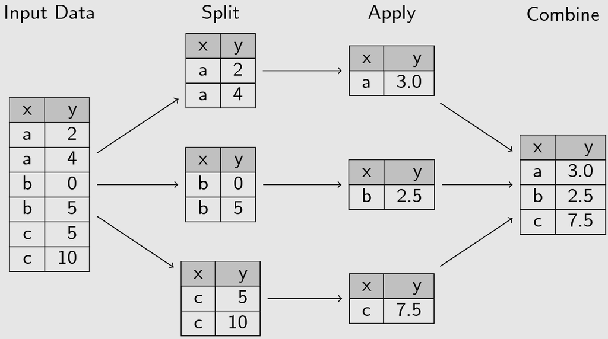

This pattern is performed in R using `dplyr`’s `group_by` and `summarise()` functions.

```
data |>
group_by(col1) |>
summarise(mean_col2 = mean(col2))
```

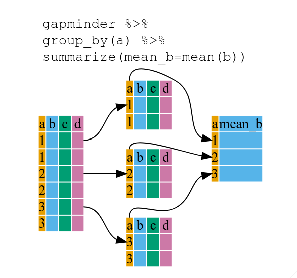

Lots more fun things you can do, see the [data transformation with dplyr cheatsheet](https://github.com/rstudio/cheatsheets/blob/main/data-transformation.pdf)

### Exercise - Manipulating Groups

#### Setup script

```r
library(tidyverse)
brauer <- read_csv(file="https://raw.githubusercontent.com/UEA-Cancer-Genetics-Lab/Using-R-with-biological-datasets-2025/a51b10274d020b15453e6ee0ab7f6e7963327bd5/data/brauer2007_tidy.csv")
```

#### Tasks

1. When the growth rate is restricted to 0.05, what is the average expression level across all genes in the “response to stress” biological process, separately for each limiting nutrient? *Hint:* 3 pipes: `filter`, `group_by`, `summarise`.
2. What about genes in the “protein biosynthesis” biological process?

#### Answer

```r
library(tidyverse)
brauer <- read_csv(file="https://raw.githubusercontent.com/UEA-Cancer-Genetics-Lab/Using-R-with-biological-datasets-2025/a51b10274d020b15453e6ee0ab7f6e7963327bd5/data/brauer2007_tidy.csv")
#1
brauer |> filter(rate == 0.05 & bp == "response to stress") |>
  group_by(nutrient) |>
  summarise(mean_expr = mean(expression, na.rm = TRUE))
```

```
# A tibble: 6 × 2
  nutrient  mean_expr
  <chr>         <dbl>
1 Ammonia       0.943
2 Glucose       0.743
3 Leucine       0.811
4 Phosphate     0.981
5 Sulfate       0.743
6 Uracil        0.731
```

```r
#2
brauer |> filter(rate == 0.05 & bp == "protein biosynthesis") |>
  group_by(nutrient) |>
  summarise(mean_expr = mean(expression, na.rm = TRUE))
```

```
# A tibble: 6 × 2
  nutrient  mean_expr
  <chr>         <dbl>
1 Ammonia      -1.61
2 Glucose      -0.691
3 Leucine      -0.574
4 Phosphate    -0.750
5 Sulfate      -0.913
6 Uracil       -0.880
```

### Advanced stretch exercise

#### Introduction

Needed new functions:

- `n_distinct()` within a `summarise()` call gives you the number of distinct values of a variable
- `slice_head(n=10)` gives the top `n` rows of a data frame.

#### Tasks

1. Which 10 biological process annotations have the most genes associated with them? *Hint:* 4 pipes: `group_by`, `summarise` with `n_distinct`, `arrange`, `slice_head`. (You could replace `arrange` and `slice_head` with `slice_max`)
2. What about molecular functions?
3. When the growth rate is restricted to 0.05 by limiting Glucose, which biological processes are the most upregulated? Show a sorted list with the most upregulated BPs on top, displaying the biological process and the average expression of all genes in that process rounded to two digits. *Hint:* 5 pipes: `filter`, `group_by`, `summarise`, `mutate`, `arrange`.

# Statistics basics

## GGplot2 reminder

ggplot2 is built on the grammar of graphics, the idea that any plot can be built from the same set of components: a **data set**, **mapping aesthetics**, and graphical **layers**:

- **Data sets** are the data that you, the user, provide.
- **Mapping aesthetics** are what connect the data to the graphics. They tell ggplot2 how to use your data to affect how the graph looks, such as changing what is plotted on the X or Y axis, or the size or color of different data points.
- **Layers** are the actual graphical output from ggplot2. Layers determine what kinds of plot are shown (scatterplot, histogram, etc.), the coordinate system used (rectangular, polar, others), and other important aspects of the plot. The idea of layers of graphics may be familiar to you if you have used image editing programs like Photoshop, Illustrator, or Inkscape.

For more information please see this [cheat sheet](https://rstudio.github.io/cheatsheets/data-visualization.pdf).

Example:

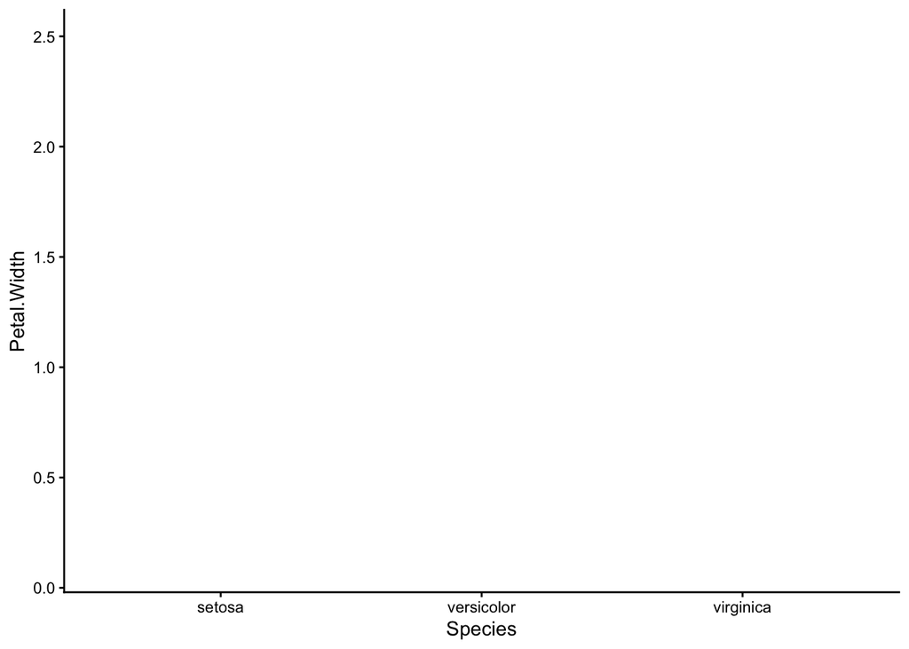

```r
library(datasets)
data(iris)
ggplot(data = iris, mapping = aes(x=Species, y=Petal.Width, colour = Species))
```

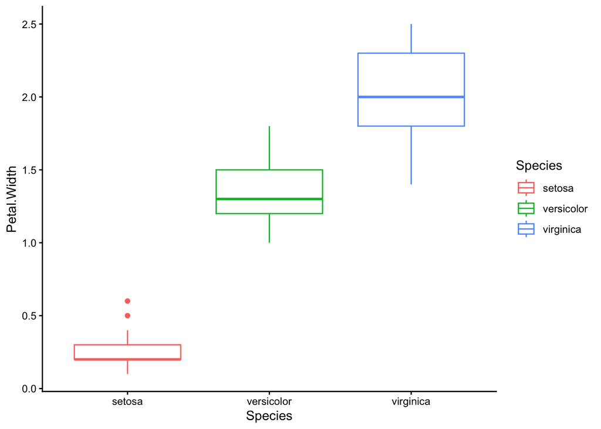

```r
ggplot(data = iris, mapping = aes(x=Species, y=Petal.Width, colour = Species)) +
    geom_boxplot()
```

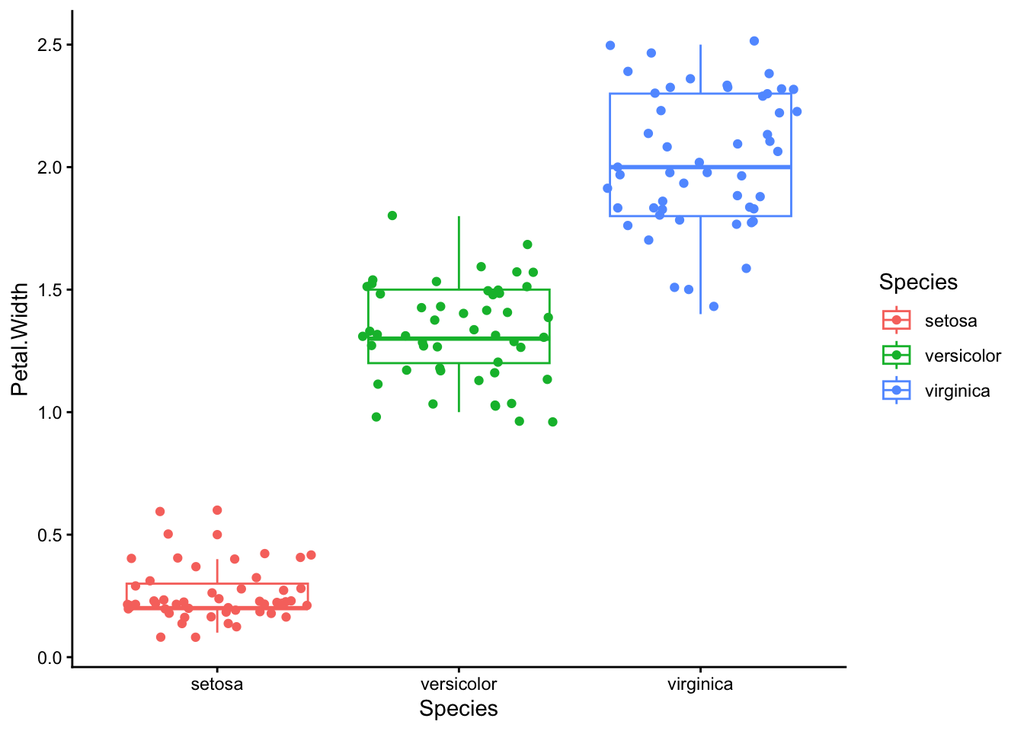

```r
ggplot(data = iris, mapping = aes(x=Species, y=Petal.Width, colour = Species)) +
    geom_boxplot() +
    geom_jitter()
```

## Descriptive statistics of a single variable

The term descriptive statistics refers to **the act of describing and summarising data**. This can be done using tables, plots, charts and key descriptive values such as the size of the dataset, percentages, average values and measures of spread.

A lot of the descriptive statistics that we are interested in reported can be gained quickly using the Exploratory Data Analysis functions we have already encountered i.e. `summary()` and `skim()`.

### Continuous variables

- `mean(x)` - The arithmetic mean of the values in *x* is computed i.e. find the sum of all values, and divide the sum by the number of values.
- `sd(x)` - computes the standard deviation of the values in *x*. Standard deviation is a measure that describes how much data points in a dataset deviate from the mean (average) value.
- `median(x)` - computes the median average of the values in *x*. The median is the value that’s exactly in the middle of a dataset when it is ordered.
- `IQR(x)` - calculates the interquartile range of the values in *x*. The interquartile range is a measure of statistical dispersion, which is the spread of the data. It is the 75th percentile value minus the 25th percentile value.

```r
iris |> pull(Petal.Length) |> mean(na.rm=TRUE)
```

```
[1] 3.758
```

```r
iris |> pull(Petal.Length) |> sd(na.rm=TRUE)
```

```
[1] 1.765298
```

```r
iris |> pull(Petal.Length) |> median(na.rm=TRUE)
```

```
[1] 4.35
```

```r
iris |> pull(Petal.Length) |> IQR(na.rm=TRUE)
```

```
[1] 3.5
```

It can also be useful to plot the distribution of a continuous variable using a histogram or density plot.

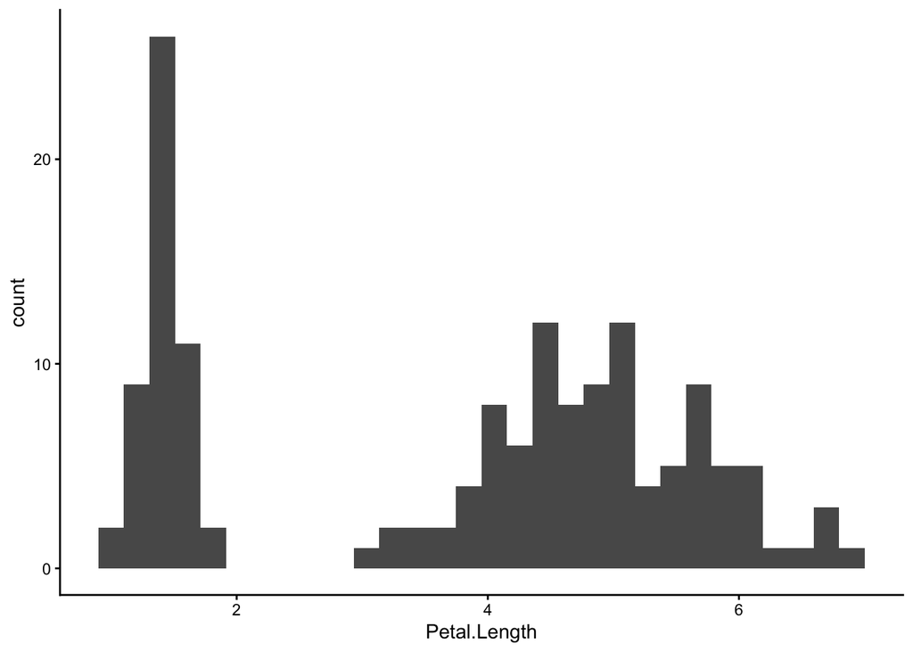

```r
ggplot(iris, aes(x=Petal.Length)) + geom_histogram()
```

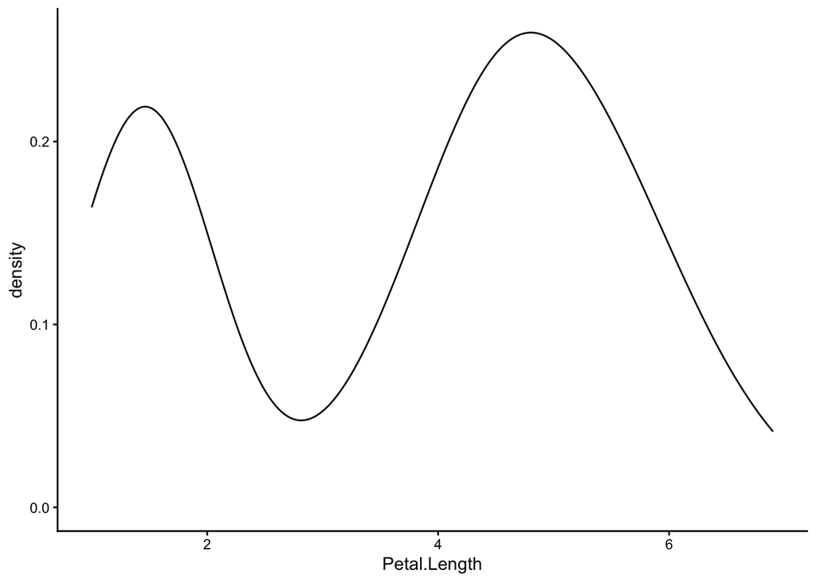

```r
ggplot(iris, aes(x=Petal.Length)) + geom_density()
```

### Categorical variables i.e. factors

For categorical variables you would summarise by counting the number in each category.

```
> penguins |> count(island)

     island   n
1    Biscoe 168
2     Dream 124
3 Torgersen  52
```

This can be visualised using a barplot.

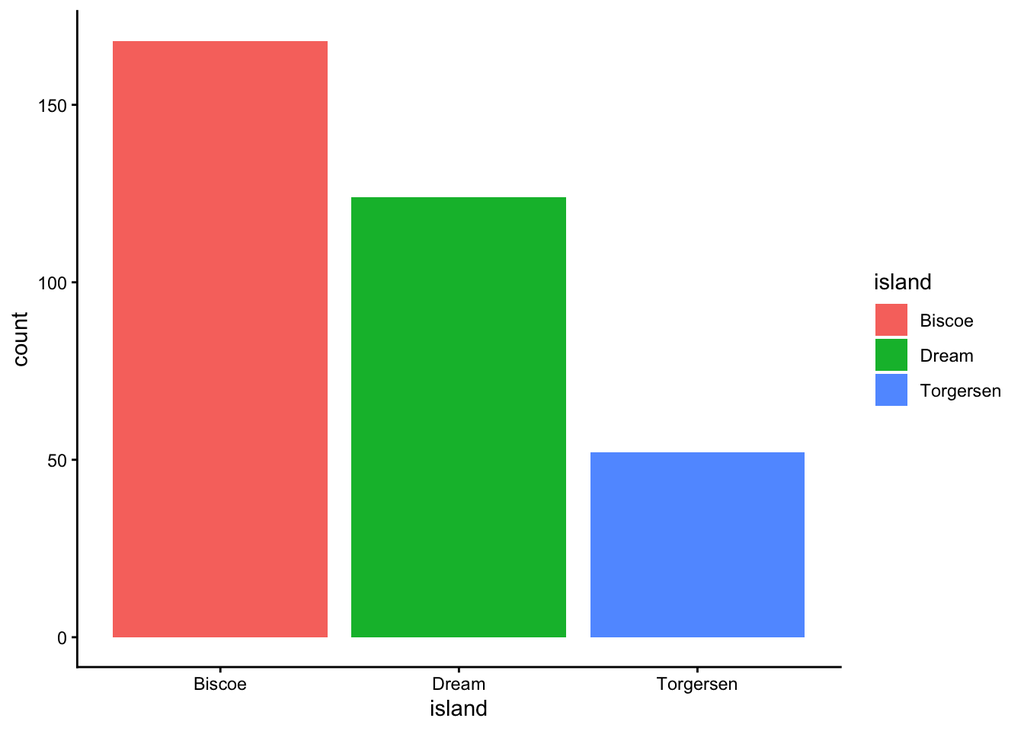

```r
ggplot(penguins, aes(x = island, fill = island)) + geom_bar()
```

### Exercise - Descriptive statistics of a single variable

#### Introduction

Here we are going to use the `penguins` data from the `palmerpenguins` dataset.

#### Setup script

```r
library(tidyverse)
library(palmerpenguins)
```

#### Tasks

Find:

1. The number of each species.
2. Produce a bar plot of the above.
3. The mean and standard deviation of the bill depth in mm.
4. The median and interquartile range of the bill length in mm.
5. Plot a histogram of the body mass in grams of the penguins

#### Answer

```r
library(tidyverse)
library(palmerpenguins)

#1
penguins |> count(species)
```

```
# A tibble: 3 × 2
  species       n
  <fct>     <int>
1 Adelie      152
2 Chinstrap    68
3 Gentoo      124
```

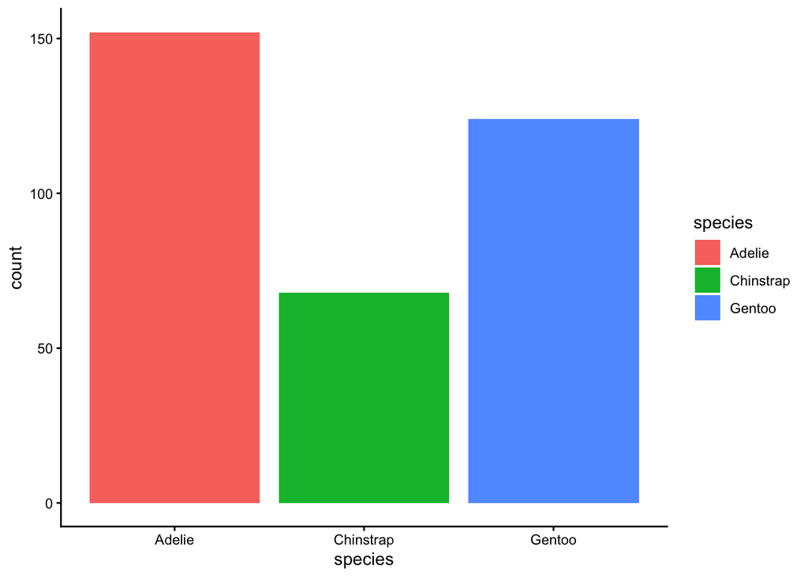

```r
#2
ggplot(penguins, aes(x = species, fill = species)) + geom_bar()
```

```r
#3
penguins |> pull(bill_depth_mm) |> mean(na.rm = TRUE)
```

```
[1] 17.15117
```

```r
penguins |> pull(bill_depth_mm) |> sd(na.rm = TRUE)
```

```
[1] 1.974793
```

```r
#4
penguins |> pull(bill_length_mm) |> median(na.rm = TRUE)
```

```
[1] 44.45
```

```r
penguins |> pull(bill_length_mm) |> IQR(na.rm = TRUE)
```

```
[1] 9.275
```

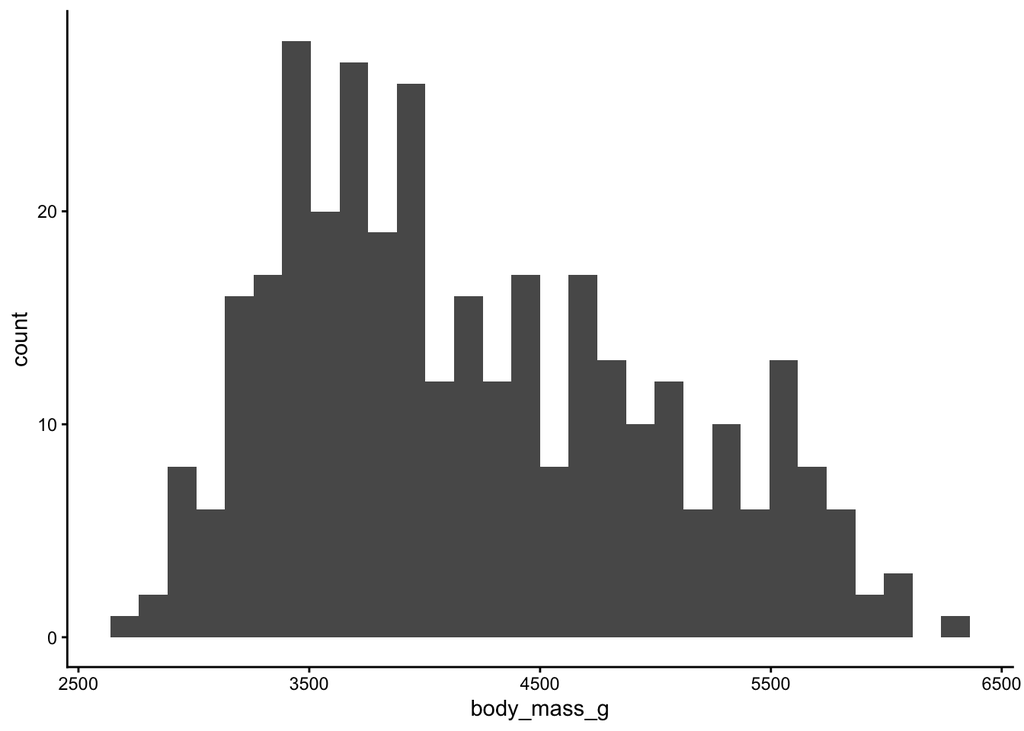

```r
#5
ggplot(penguins, aes(x = body_mass_g)) + geom_histogram()
```

## For a continuous variable are the average values of two groups different?

One of the most common questions that researchers ask is, “Do we have evidence that the average value of a trait in one group differs from the average for another group?”.

### *t*-tests

This is the most commonly used approach.

#### Assumptions

- The data are continuous.
- The sample data have been randomly sampled from a population.
- The distribution is approximately normal.

#### Example

```r
# Preparing a suitable dataset
peng_means <- penguins |>
  filter(species %in% c("Adelie","Gentoo") & !is.na(bill_depth_mm)) |>
  mutate(species = factor(species))

ttest_res <- t.test(bill_depth_mm ~ species, data = peng_means)

print(ttest_res)
```

```
    Welch Two Sample t-test

data:  bill_depth_mm by species
t = 25.337, df = 271.98, p-value < 2.2e-16
alternative hypothesis: true difference in means between group Adelie and group Gentoo is not equal to 0
95 percent confidence interval:
 3.102837 3.625651
sample estimates:
mean in group Adelie mean in group Gentoo
            18.34636             14.98211
```

```r
print(ttest_res$p.value)
```

```
[1] 1.505948e-73
```

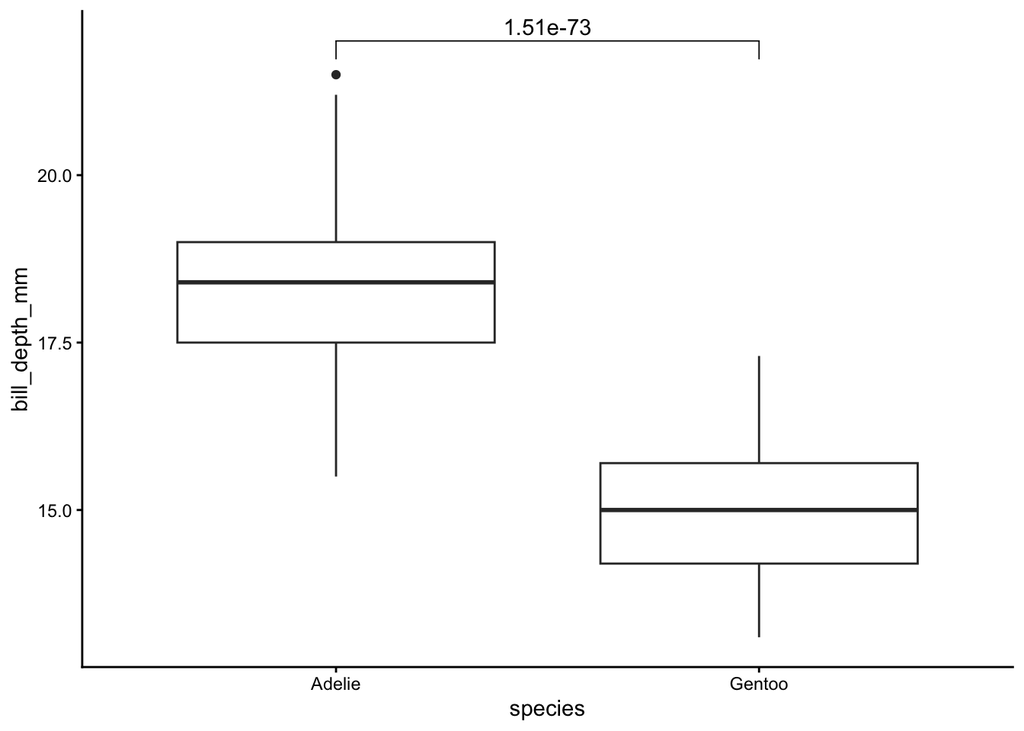

```r
library(tidyverse)
library(palmerpenguins)
library(rstatix)
library(ggpubr)

ttest_res <- peng_means |>
  t_test(bill_depth_mm ~ species) |>
  add_xy_position()

ggplot(peng_means, aes(x = species, y = bill_depth_mm)) +
    geom_boxplot() +
    stat_pvalue_manual(ttest_res)
```

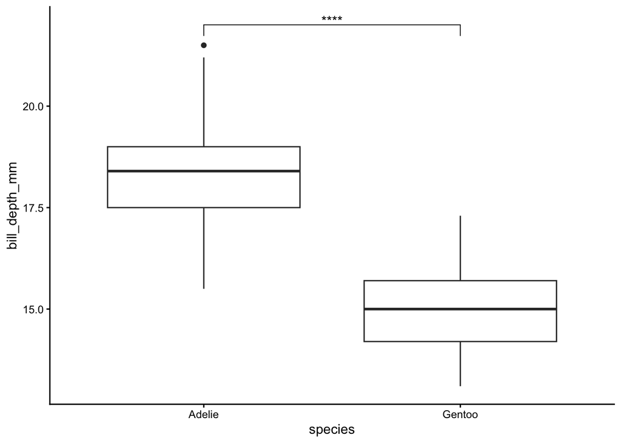

```r
ttest_res <- peng_means |>
  t_test(bill_depth_mm ~ species) |>
  add_xy_position() |>
  add_significance()

ggplot(peng_means, aes(x = species, y = bill_depth_mm)) +
    geom_boxplot() +
    stat_pvalue_manual(ttest_res, label = "p.signif")
```

By default R uses the Welch two-sample *t*-test rather than Student’s two sample *t*-test. This is a good idea as it means we don’t have to assume that the variability of the data in each group is similar.

#### Testing the distribution is approximately normal.

There are two main approaches to testing the normal distribution: visual examination through plots and normality tests.

One way is to plot the distribution using a histogram.

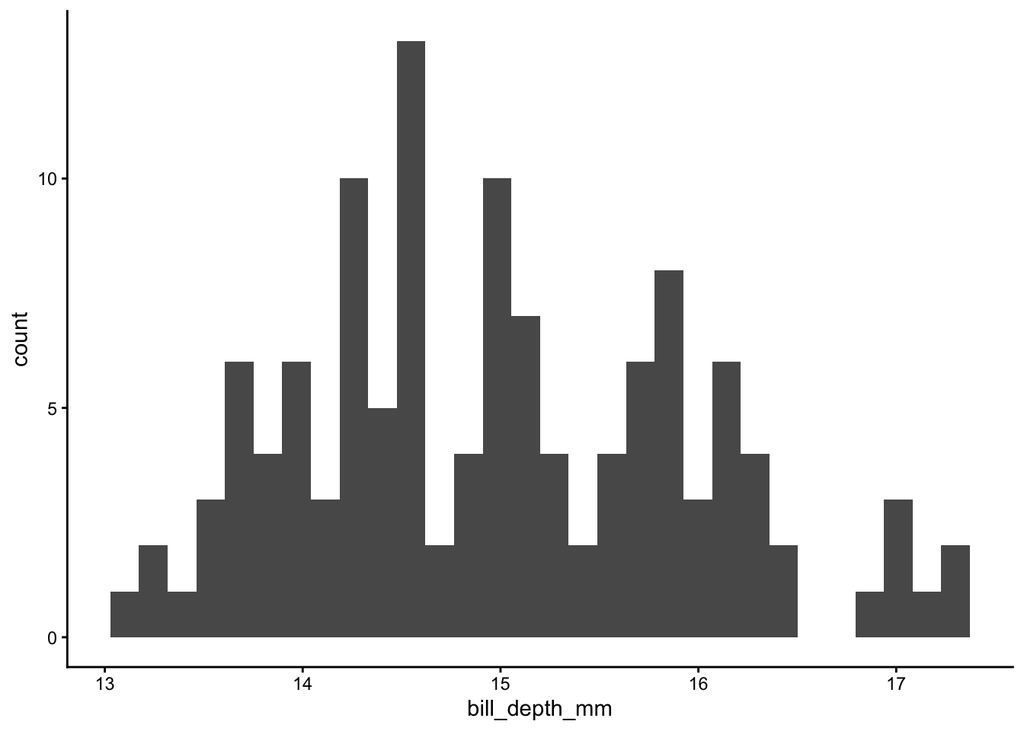

```r
ggplot(penguins |> filter(species == "Gentoo"), aes(x=bill_depth_mm)) +
  geom_histogram()
```

A QQ plot, or Quantile-Quantile plot, is a graphical tool used to assess whether a dataset follows a specific theoretical distribution, often a normal distribution. It does this by plotting the quantiles of the observed data against the quantiles of the theoretical distribution.

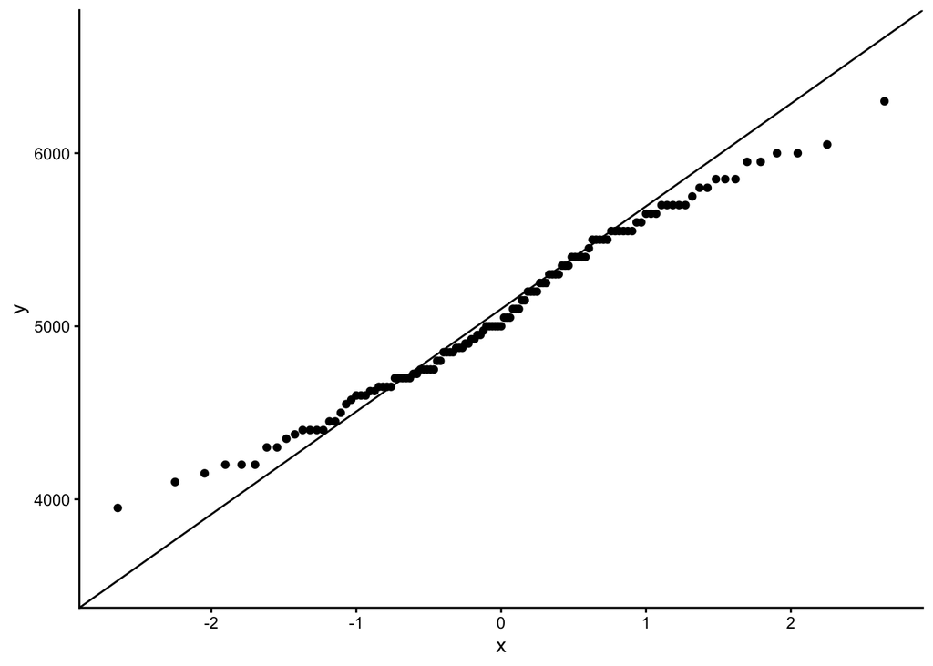

```r
ggplot(penguins |> filter(species == "Gentoo"), aes(sample=body_mass_g)) +
  geom_qq() +
  geom_qq_line()
```

The most common statistical test for normality is the Shapiro-Wilk test. The Shapiro-Wilk test is a goodness-of-fit whose null hypothesis is that the sample has been generated from a normal distribution. Therefore if *p* < 0.05, the distribution is thought to be not normal.

```r
test_col <- penguins |> filter(species == "Gentoo") |> pull(body_mass_g)
shapiro.test(test_col)
```

```
    Shapiro-Wilk normality test

data:  test_col
W = 0.98593, p-value = 0.2336
```

**Note**

The use of normality tests such as Shapiro–Wilk is controversial and are thought, by some, to be absolutely useless for the following reasons:

- On small samples, there’s a good chance that the true distribution of the population is substantially non-normal, but the normality test isn’t powerful to pick it up.
- On large samples, things like the *t*-test and ANOVA are pretty robust to non-normality.
- The whole idea of a normally distributed population is just a convenient mathematical approximation anyhow.

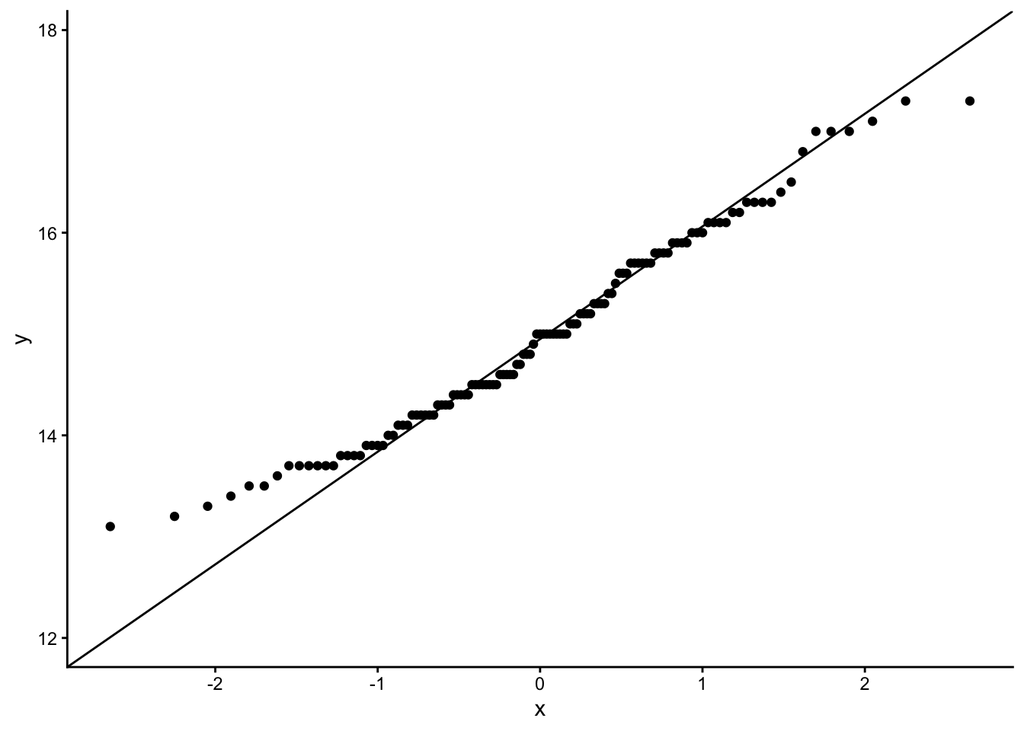

```r
ggplot(penguins |> filter(species == "Gentoo"), aes(sample=bill_depth_mm)) +
  geom_qq() +
  geom_qq_line()
```

```r
test_col <- penguins |> filter(species == "Gentoo") |> pull(bill_depth_mm)
shapiro.test(test_col)
```

```
    Shapiro-Wilk normality test

data:  test_col
W = 0.97609, p-value = 0.0277
```

### Mann-Whitney U test

What do you do if the distribution of values doesn’t follow a normal distribution?

1. Transform the data so it is normally distributed e.g. $log$ transformation.
2. You use a non-parametric tests i.e. a statistical methods that don’t assume a specific distribution for the data.

The Mann-Whitney U Test, also known as the Wilcoxon Rank Sum Test, is a non-parametric statistical test used to compare the medians of two groups.

#### Example

```r
wilcox.test(bill_depth_mm ~ species, data = peng_means)
```

```
    Wilcoxon rank sum test with continuity correction

data:  bill_depth_mm by species
W = 18320, p-value < 2.2e-16
alternative hypothesis: true location shift is not equal to 0
```

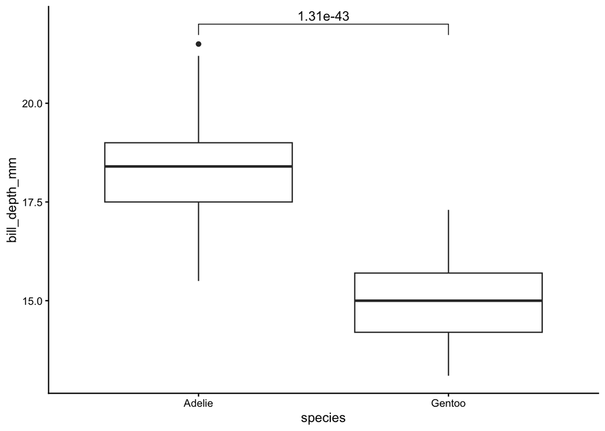

```r
library(tidyverse)
library(palmerpenguins)
library(rstatix)
library(ggpubr)

wilcox_res <- peng_means |>
  wilcox_test(bill_depth_mm ~ species) |>
  add_xy_position()

ggplot(peng_means, aes(x = species, y = bill_depth_mm)) +
    geom_boxplot() +
    stat_pvalue_manual(wilcox_res)
```

### Exercise - *t*-test etc.

#### Introduction

In this exercise will will be looking at a 16S sequencing data for the abundance of the genus Arcanobacterium in urine samples from clinically benign and prostate cancer patients (high-risk aggressive form).

#### Setup script

```r
library(tidyverse)
library(rstatix)
library(ggpubr)
dat_16S <- read_csv( "https://raw.githubusercontent.com/UEA-Cancer-Genetics-Lab/Using-R-with-biological-datasets-2025/a51b10274d020b15453e6ee0ab7f6e7963327bd5/data/Arcanobacterium_16S.csv")
```

#### Tasks

1. Determine whether there is a differential abundance for the abundance of Arcanobacterium (column = `Arcanobacterium`) between aggressive prostate cancer (H) and clinically benign (CB) patients (column = `primaryCat`), using a Welch *t* test.
2. Create a plot
3. Is it significantly different? In what direction
4. Repeat using a Mann-Whitney U test
5. (stretch) What test is more appropriate in this situation?
6. (stretch) Look at the file `16S_Community.tsv` and repeat with other genus (`read_csv("https://github.com/UEA-Cancer-Genetics-Lab/Using-R-with-biological-datasets-2025/blob/a51b10274d020b15453e6ee0ab7f6e7963327bd5/data/16s_Community.tsv")`).

#### Answers

```r
library(tidyverse)
library(rstatix)
library(ggpubr)
dat_16S <- read_csv( "https://raw.githubusercontent.com/UEA-Cancer-Genetics-Lab/Using-R-with-biological-datasets-2025/refs/heads/main/data/Arcanobacterium_16S.csv")

#1
t.test(Arcanobacterium ~ primaryCat, dat = dat_16S)
```

```
    Welch Two Sample t-test

data:  Arcanobacterium by primaryCat
t = 2.9236, df = 9.2518, p-value = 0.01646
alternative hypothesis: true difference in means between group CB and group H is not equal to 0
95 percent confidence interval:
 0.01898677 0.14652369
sample estimates:
mean in group CB  mean in group H
     0.089785876      0.007030646
```

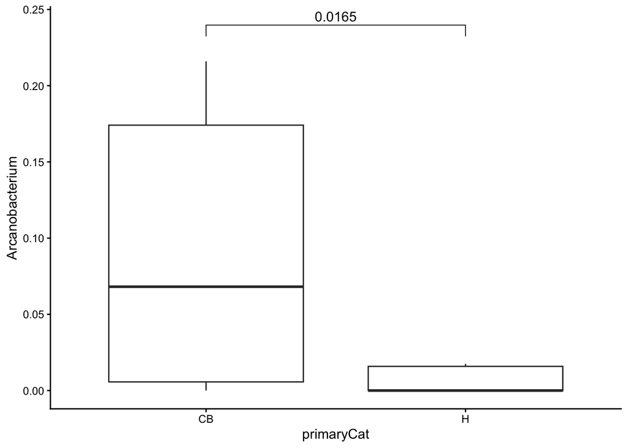

```r
#2
ttest_res <- dat_16S |>
  t_test(Arcanobacterium ~ primaryCat) |>
  add_xy_position() |>
  add_significance()

ggplot(dat_16S, aes(x = primaryCat, y = Arcanobacterium)) +
    geom_boxplot() +
    stat_pvalue_manual(ttest_res, label = "p")
```

```r
#3
# Yes it is significantly different with a p = 0.016. It is significantly less abundant in high risk patients compared to clinically benign.

#4
wilcox.test(Arcanobacterium ~ primaryCat, dat = dat_16S)
```

```
    Wilcoxon rank sum test with continuity correction

data:  Arcanobacterium by primaryCat
W = 55, p-value = 0.04862
alternative hypothesis: true location shift is not equal to 0
```

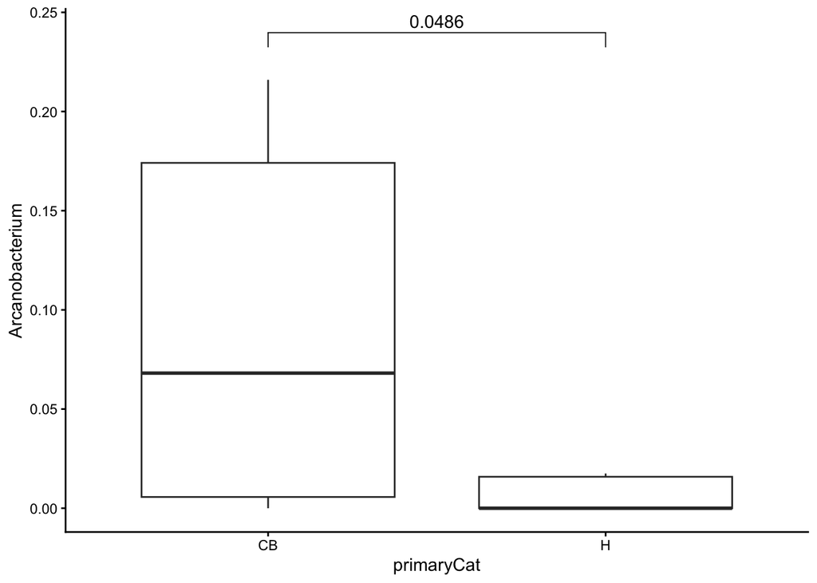

```r
wilcox_res <- dat_16S |>
  wilcox_test(Arcanobacterium ~ primaryCat) |>
  add_xy_position() |>
  add_significance()

ggplot(dat_16S, aes(x = primaryCat, y = Arcanobacterium)) +
    geom_boxplot() +
    stat_pvalue_manual(wilcox_res, label = "p")
```

### Variations

Variations that we will not discuss today:

- Comparing a distribution to a fixed-value - One-sample statistical test
- Comparing groups when you know the direction i.e. is x larger than y, one-tailed test as compared to the normal two-tailed test.
- When measurements are linked in some way e.g. two qPCRs for different probes on the same set of samples i.e. a paired statistical test

### Multiple “probes” at the same time

The real power of R comes when you need to do statistical tests on a large number of times e.g. for every genus detected. Here is an example:

```r
dat <- read_delim("data/16s_Community.tsv")

dat_longer <- dat |>
  filter(primaryCat %in% c("CB","H")) |>
  pivot_longer(2:158)

ttest_res <- dat_longer |>
  group_by(name) |>
  t_test(value~primaryCat) |>
  adjust_pvalue(method = "BH") |>
  filter(!is.na(p)) |>
  arrange(p)

ttest_res
```

```
# A tibble: 133 × 10
   name             .y.   group1 group2    n1    n2 statistic    df      p p.adj
   <chr>            <chr> <chr>  <chr>  <int> <int>     <dbl> <dbl>  <dbl> <dbl>
 1 D_5__Arcanobact… value CB     H         10     7      2.92  9.25 0.0165 0.520
 2 D_5__Undibacter… value CB     H         10     7      1.90 10.7  0.0846 0.520
 3 D_5__S5-A14a     value CB     H         10     7      1.79  9.11 0.106  0.520
 4 D_4__Family XI;… value CB     H         10     7      1.76 10.9  0.107  0.520
 5 D_5__Sutterella  value CB     H         10     7      1.63  9.41 0.137  0.520
 6 D_5__Ralstonia   value CB     H         10     7      1.55 11.4  0.149  0.520
 7 D_5__Fastidiosi… value CB     H         10     7      1.45 13.9  0.169  0.520
 8 D_5__Allorhizob… value CB     H         10     7      1.49  9    0.172  0.520
 9 D_5__Howardella  value CB     H         10     7     -1.54  6    0.175  0.520
10 D_4__Ruminococc… value CB     H         10     7      1.47  9    0.177  0.520
# ℹ 123 more rows
```

Note: When looking at a large number of tests at the same time it is important to perform a multiple testing correction to any *p*-value. We would recommend Benjamini-Hochberg.

### Are there differences in the means of three or more groups?

The main statistical test to do this is the One-way ANOVA (analysis of variance).

If the test is significant then it tells us that at least one pair of means is significantly different, **but it can’t tell us which pair**. For that you need *post-hoc* tests such as Tukey Honest Significant Differences, or a multiple-testing corrected set of pairwise *t*-tests.

As with the *t*-test, ANOVA assumes that the variable is normally distributed in each of the groups and that the variability within groups is similar across groups. Look at [Kruskal-Wallis test](https://www.sthda.com/english/wiki/kruskal-wallis-test-in-r) for a non-parametric alternative (use, for example, the Dunn test for a post-hoc test).

### Example

#### Anova model

```r
anova_res <- aov(bill_depth_mm ~ species, data = penguins)

print(summary(anova_res))
```

```
             Df Sum Sq Mean Sq F value Pr(>F)
species       2  904.0   452.0   359.8 <2e-16 ***
Residuals   339  425.9     1.3
---
Signif. codes:  0 '***' 0.001 '**' 0.01 '*' 0.05 '.' 0.1 ' ' 1
2 observations deleted due to missingness
```

#### Post-hoc tests

```r
TukeyHSD(anova_res)
```

```
  Tukey multiple comparisons of means
    95% family-wise confidence level

Fit: aov(formula = bill_depth_mm ~ species, data = penguins)

$species
                        diff        lwr        upr     p adj
Chinstrap-Adelie  0.07423062 -0.3110995  0.4595607 0.8928875
Gentoo-Adelie    -3.36424379 -3.6847143 -3.0437733 0.0000000
Gentoo-Chinstrap -3.43847441 -3.8371903 -3.0397586 0.0000000
```

#### Plot

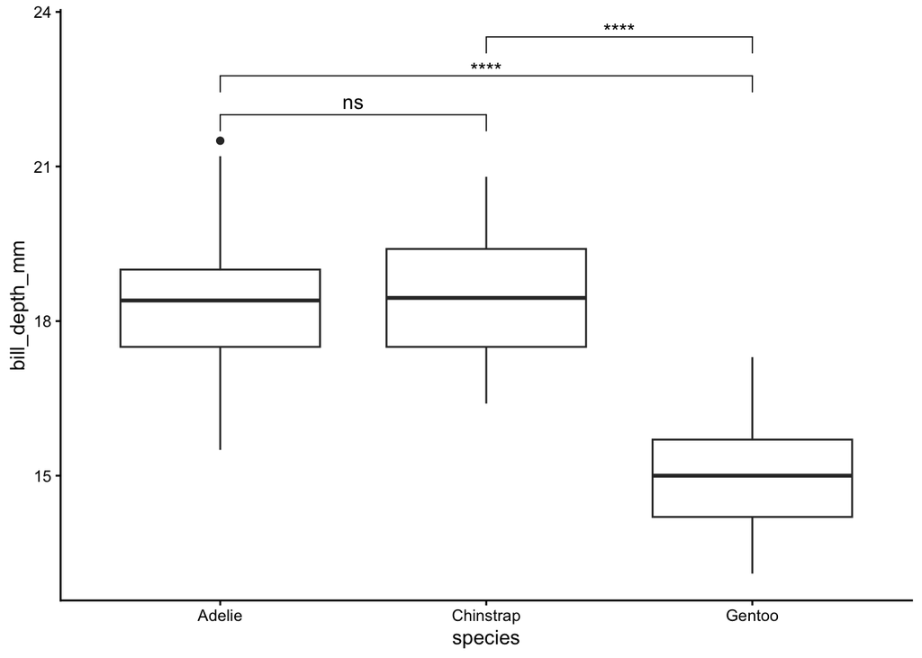

```r
tukey_res <- penguins |>
  tukey_hsd(bill_depth_mm ~ species) |>
  add_xy_position() |>
  add_significance()

ggplot(penguins, aes(x=species, y=bill_depth_mm)) +
  geom_boxplot() +
  stat_pvalue_manual(tukey_res, label = "p.adj.signif")
```

### Exercise - ANOVA

#### Introduction

For this exercise we will be using an adapted version of data published by [Ametaj BN, et al.](https://link.springer.com/article/10.1007/s11306-010-0227-6), showing metabolite concentrations of 39 rumen samples measured by proton NMR from dairy cows fed with different proportions of barley grain.

#### Setup script

```r
library(tidyverse)
library(rstatix)
library(ggpubr)

cow_diet <- read_rds("https://github.com/UEA-Cancer-Genetics-Lab/Using-R-with-biological-datasets-2025/raw/refs/heads/main/data/cow_diet.rds")
```

#### Tasks

1. Determine whether there are any differences in the means of uracil between the diets, using ANOVA and the Tukey Honest Significant Differences test.
2. Make an appropriate plot.
3. (Stretch) Repeat with the other metabolites i.e. “x3_hp”, “glutamate”, “proline”, “uracil” “xanthine”.

#### Answer

```r
library(tidyverse)
library(rstatix)
library(ggpubr)
cow_diet <- read_rds("https://github.com/UEA-Cancer-Genetics-Lab/Using-R-with-biological-datasets-2025/raw/refs/heads/main/data/cow_diet.rds")

#1
aov_cow <- aov(uracil ~ diet, data = cow_diet)
summary(aov_cow)
```

```
            Df Sum Sq Mean Sq F value   Pr(>F)
diet         2  84681   42341   19.51 1.82e-06 ***
Residuals   36  78114    2170
---
Signif. codes:  0 '***' 0.001 '**' 0.01 '*' 0.05 '.' 0.1 ' ' 1
```

```r
TukeyHSD(aov_cow)
```

```
  Tukey multiple comparisons of means
    95% family-wise confidence level

Fit: aov(formula = uracil ~ diet, data = cow_diet)

$diet
         diff      lwr       upr     p adj
B-A  77.79333 32.09202 123.49464 0.0005400
C-A 133.25333 80.93891 185.56776 0.0000010
C-B  55.46000 11.36275  99.55725 0.0109273
```

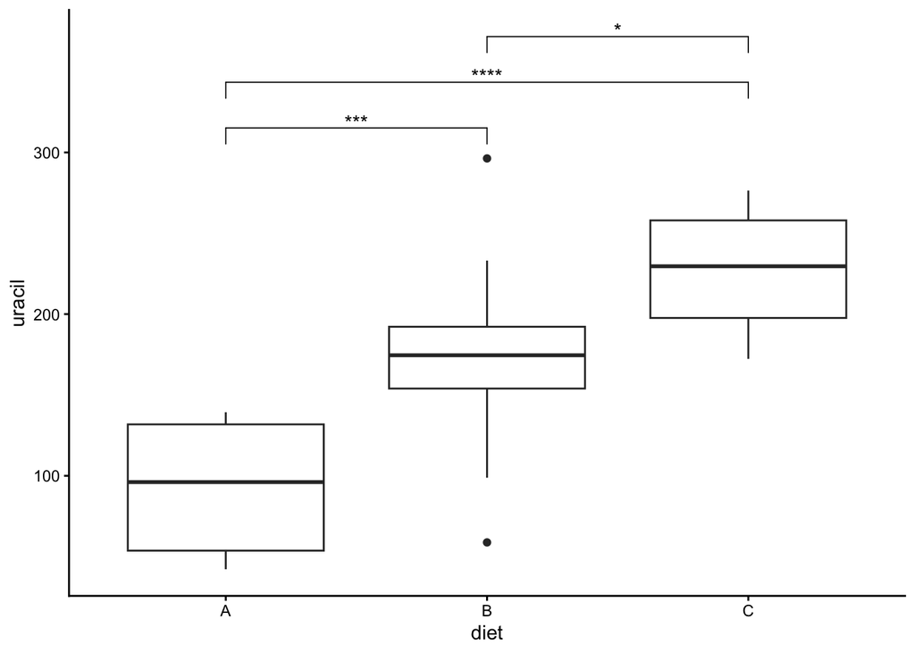

```r
#2
tukey_res <- cow_diet |>
  tukey_hsd(uracil ~ diet) |>
  add_xy_position() |>
  add_significance()

ggplot(cow_diet, aes(x=diet, y=uracil)) +
  geom_boxplot() +
  stat_pvalue_manual(tukey_res, label = "p.adj.signif")
```

## Is there a significant relationship between two continuous measurements?

Correlation Analysis is a statistical method that is used to discover if there is a relationship between two sets of measurements that are continuous, and how strong that relationship may be.

Remember “Correlation is not causation”. Correlation is used in everyday life to denote some form of association.

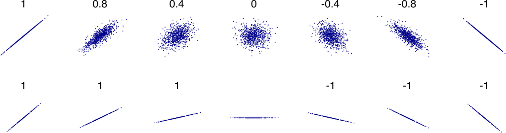

Two key types of correlation to know about:

1. Pearson’s correlation coefficient. It is a measure of linear association and assesses how good a “line of best fit” is. The coefficient is often denoted by the letter $r$.
2. Spearman’s rank correlation coefficient. It is a rank correlation coefficients and measures the extent to which, as one variable increases, the other variable tends to increase, without requiring that increase to be represented by a linear relationship. The coefficient is often denoted by the Greek letter $\rho$.

Example:

```r
# Pearson's
cor.test(penguins$flipper_length_mm, penguins$body_mass_g, use="pairwise.complete.obs")
```

```
    Pearson's product-moment correlation

data:  penguins$flipper_length_mm and penguins$body_mass_g
t = 32.722, df = 340, p-value < 2.2e-16
alternative hypothesis: true correlation is not equal to 0
95 percent confidence interval:
 0.843041 0.894599
sample estimates:
      cor
0.8712018
```

```r
# Spearman
cor.test(penguins$flipper_length_mm, penguins$body_mass_g, use="pairwise.complete.obs", method="spearman")
```

```
    Spearman's rank correlation rho

data:  penguins$flipper_length_mm and penguins$body_mass_g
S = 1066875, p-value < 2.2e-16
alternative hypothesis: true rho is not equal to 0
sample estimates:
      rho
0.8399741
```

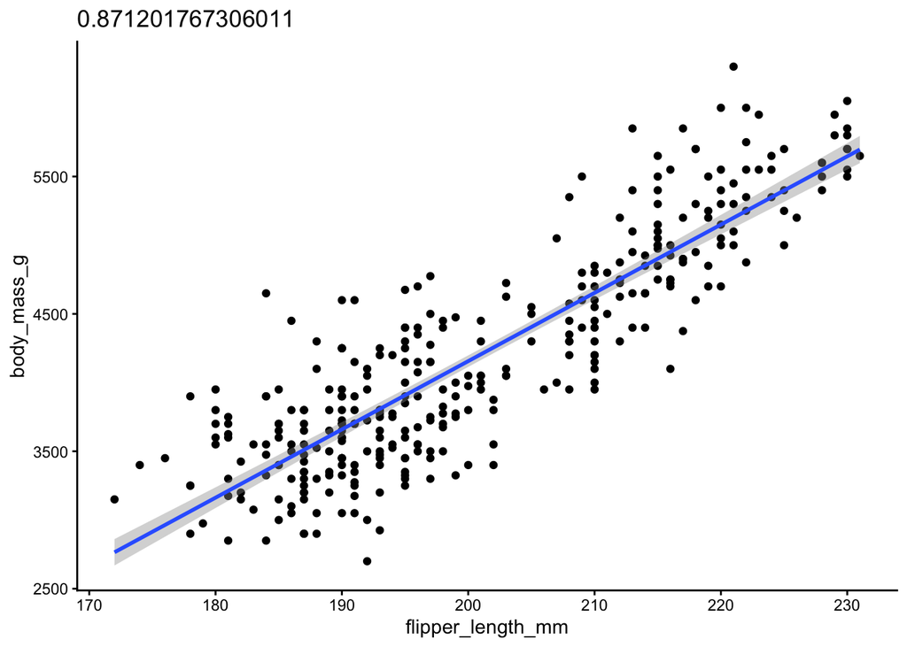

```r
cor_res <- cor(penguins$flipper_length_mm, penguins$body_mass_g, use="pairwise.complete.obs")

ggplot(penguins, aes(x=flipper_length_mm, y=body_mass_g)) +
    geom_point() +
    geom_smooth(method="lm") +
    ggtitle(cor_res)
```

### Exercise - Correlation

#### Introduction

Again, we will be using an adapted version of data published by [Ametaj BN, et al.](https://link.springer.com/article/10.1007/s11306-010-0227-6), showing metabolite concentrations of 39 rumen samples measured by proton NMR from dairy cows fed with different proportions of barley grain.

#### Setup script

```r
library(tidyverse)
cow_diet <- read_rds("https://github.com/UEA-Cancer-Genetics-Lab/Using-R-with-biological-datasets-2025/raw/refs/heads/main/data/cow_diet.rds")
```

#### Tasks

1. Fine the Pearson’s correlation between the metabolites uracil and xanthine.
2. Create a related plot.
3. (stretch) Repeat with other pairs of metabolite.

#### Answers

```r
library(tidyverse)
cow_diet <- read_rds("https://github.com/UEA-Cancer-Genetics-Lab/Using-R-with-biological-datasets-2025/raw/refs/heads/main/data/cow_diet.rds")

#1
cor.test(cow_diet$uracil, cow_diet$xanthine, use="pairwise.complete.obs")
```

```
    Pearson's product-moment correlation

data:  cow_diet$uracil and cow_diet$xanthine
t = 7.6656, df = 37, p-value = 3.749e-09
alternative hypothesis: true correlation is not equal to 0
95 percent confidence interval:
 0.6214104 0.8810902
sample estimates:
      cor
0.7833412
```

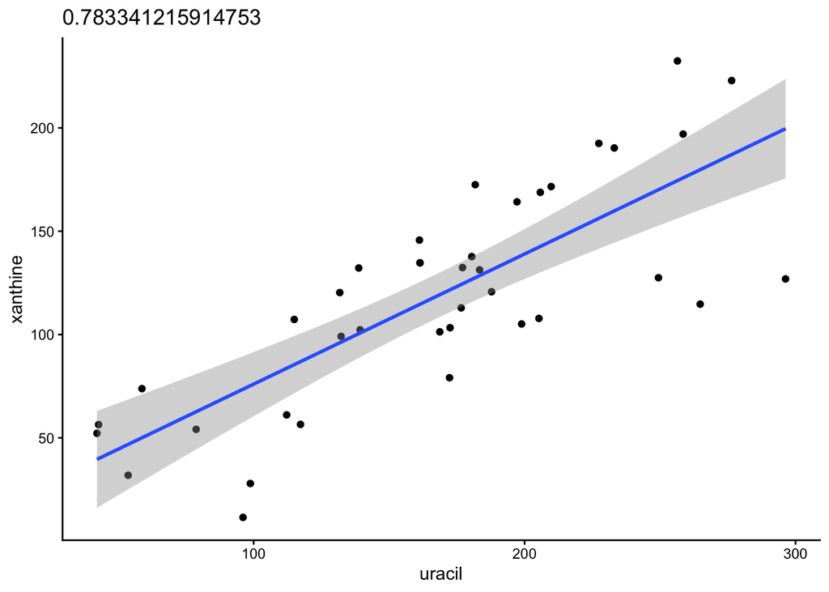

```r
#2
cor_res <- cor(cow_diet$uracil, cow_diet$xanthine, use="pairwise.complete.obs")

ggplot(cow_diet, aes(x=uracil, y=xanthine)) +
    geom_point() +
    geom_smooth(method="lm") +
    ggtitle(cor_res)
```

## Is there a relationship between two categorical variables?

Until now we’ve only discussed analysing *continuous* outcomes. We’ve tested for differences in means between two groups with *t*-tests, and differences among means between 3 or more groups with ANOVA. In all of these cases, the dependent variable or the outcome, was *continuous*. What if our outcome variable is *discrete*, e.g., “Yes/No”, “Mutant/WT”, “Case/Control”, etc.? Here we use a different set of procedures for assessing significant associations.

A **contingency table**, also known as a cross-tabulation or cross-tab, shows how the values of two or more categorical variables are distributed across their respective categories.

```r
penguins |> tabyl(island,sex, show_na = FALSE)
```

```
    island female male
    Biscoe     80   83
     Dream     61   62
 Torgersen     24   23
```

Chi-Square Test of Independence helps determine whether two categorical variables are independent or if there’s a relationship between them. For example, you might want to know if gender affects voting preference. It takes a contingency table as input.

Assumptions:

- All observations are independent.
- Cells in the contingency table are mutually exclusive
- Expected value of cells should be 5 or greater in at least 80% of cells

Example:

```r
penguins |> tabyl(island,sex, show_na = FALSE) |> chisq.test()
```

```
    Pearson's Chi-squared test

data:  tabyl(penguins, island, sex, show_na = FALSE)
X-squared = 0.057599, df = 2, p-value = 0.9716
```

```r
penguins |> tabyl(island,sex, show_na = FALSE) |> adorn_percentages("row")
```

```
    island    female      male
    Biscoe 0.4907975 0.5092025
     Dream 0.4959350 0.5040650
 Torgersen 0.5106383 0.4893617
```

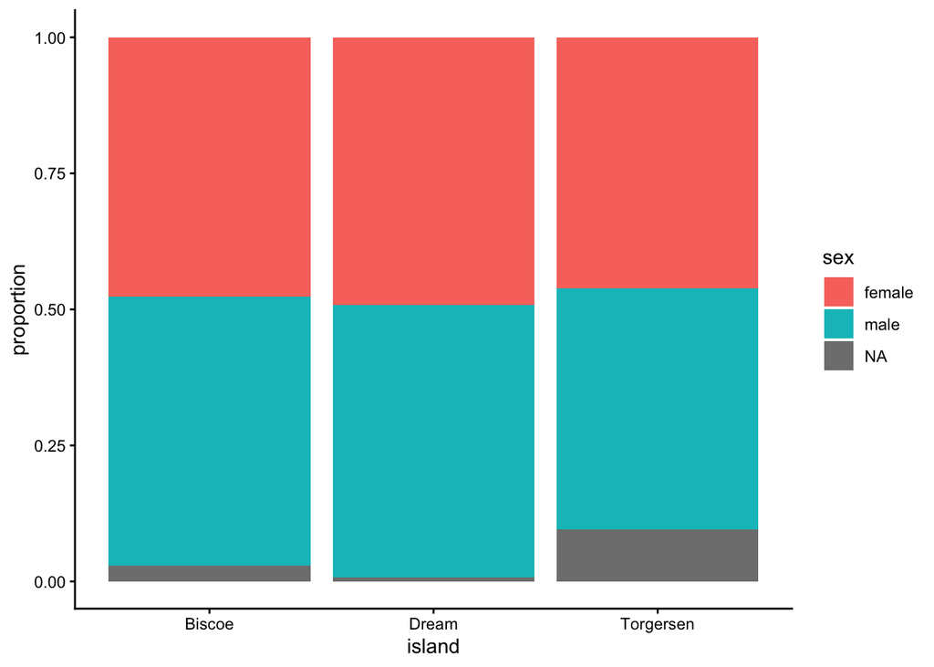

```r
ggplot(penguins, aes(x = island, fill = sex)) + geom_bar(position = "fill") + ylab("proportion")
```

Fisher Exact test can be used when some of the assumptions of the Chi-Square test are broken. We will not be going into details on this here.